# Case Study Analysis

Riccardo Bianchini

# Comparing the impact of propensity score weighting methods on causal inference using an observational case study

The study leverages openly accessible data, available on DRYAD (https://datadryad.org/stash/dataset/doi:10.5061/dryad.6qs53), that are part of the third survey of the Prevention of REnal and Vascular ENd-stage Disease (PREVEND). This observational study evaluated the association between statin use and cognitive function in a large population with more than 10-year follow-up on statin use. Additionally, it sought to determine if the duration of treatment impacted this association.

A total of 4095 patients were collected, with 904 (22%) being statin users and 3191 (78%) being non-users. The total duration of treatment in years was also assessed for statin users.

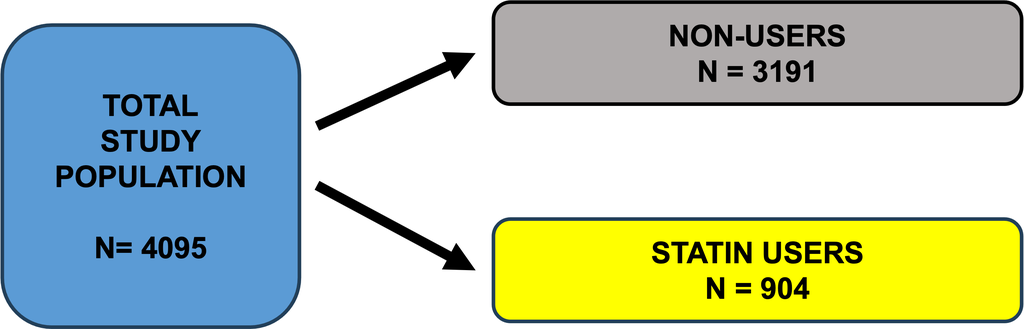

The **Ruff Figural Fluency Test (RFFT)** score was used as the primary outcome measure for cognitive function.

Baseline data about demographis, clinical characteristics and medical history were collected for each patient. In particular, the covariates that were taken into consideration for the following analyses were:

- Gender (Male/Female)
- Educational level (≤ 12 years, >12 years)
- History of vascular events (CVD) (Yes/No)
- Hypertension (Yes/No)
- Diabetes Mellitus (DM) (Yes/No)
- Smoking status (Yes/No)
- Albuminuria levels (<30 mg/24hr, ≥30 mg/24hr)
- Age (in years)
- Body Mass Index (BMI, in kg/m2)

## Libraries

The `PW.case.study.simulations` package was built to analyse both the case study and to perform simulations: by loading this, the required libraries for the analysis are loaded as well. Can be easily installed from its Github repository using the `devtools` package.

```r
library(devtools)
devtools::install_github("bianchiniriccardo95/PW.case.study.simulations")
```

After having installed it, let’s load the necessary libraries for the analysis

```r
library(PW.case.study.simulations)
library(Hmisc)
library(gtsummary)
```

## Dataset

Let’s now load the dataset, already included in the `PW.case.study.simulations` package:

```r
#The dataset is available in the PW.case.study.simulations package
data("statin_db")
statin_db <- statin_db %>%
  mutate(Albuminuria = Albuminuria_1)
```

## Covariate balance evaluation

Let’s now have a look at the distribution of the baseline covariates between the two treatment groups, in order to evaluate their balancing.

The baseline covariates, as said before, are:

- Gender (`Gender`)
- Educational Level (`Education`)
- Smoking status (`Smoking`)
- History of vascular events (`CVD`)
- Hypertension (`Hypertension`)
- Diabetes Mellitus (`DM`)
- Albuminuria Levels (`Albuminuria`)
- Age (`Age`)
- Body Mass Index (`BMI`)

```r
confounder_unbalancing <- summary(
  Statin ~ Age + Gender + Education + CVD + Smoking + DM + Hypertension + BMI + Albuminuria,
  data = statin_db,
  method = 'reverse')

print(confounder_unbalancing)
```

```
##
##
## Descriptive Statistics by Statin
##
## +------------+--------------------------+--------------------------+
## |            |0                         |1                         |
## |            |(N=3191)                  |(N=904)                   |
## +------------+--------------------------+--------------------------+
## |Age         |     44.00/51.00/60.00    |     53.75/61.00/69.00    |
## +------------+--------------------------+--------------------------+
## |Gender      |        52%  (1644)       |        34%  ( 311)       |
## +------------+--------------------------+--------------------------+
## |Education   |        65%  (2073)       |        45%  ( 411)       |
## +------------+--------------------------+--------------------------+
## |CVD         |         3%  (  92)       |        24%  ( 215)       |
## +------------+--------------------------+--------------------------+
## |Smoking     |        23%  ( 747)       |        25%  ( 225)       |
## +------------+--------------------------+--------------------------+
## |DM          |         3%  (  81)       |        19%  ( 174)       |
## +------------+--------------------------+--------------------------+
## |Hypertension|        25%  ( 809)       |        64%  ( 580)       |
## +------------+--------------------------+--------------------------+
## |BMI         |23.46539/25.73439/28.64635|25.07232/27.62324/30.69555|
## +------------+--------------------------+--------------------------+
## |Albuminuria |        10%  ( 328)       |        30%  ( 268)       |
## +------------+--------------------------+--------------------------+
```

To have a better table representation, let’s use the functions of the `gtsummary` package:

```r
statin_db_descriptives <- statin_db %>%
  mutate(
    Statin = factor(ifelse(statin_db$Statin == 1, 'Yes', 'No')),
    Education = factor(ifelse(statin_db$Education == 0, '≤12 years', '>12 years')),
    Gender = factor(ifelse(statin_db$Gender == 0, 'Male', 'Female')),
    CVD = factor(ifelse(statin_db$CVD == 1, 'Yes', 'No')),
    DM = factor(ifelse(statin_db$DM == 1, 'Yes', 'No')),
    Smoking = factor(ifelse(statin_db$Smoking == 1, 'Yes', 'No')),
    Albuminuria_1 = factor(ifelse(statin_db$Albuminuria_1 == 0, "<30", "≥30")),
    Hypertension = factor(ifelse(statin_db$Hypertension == 0, 'No', 'Yes'))
  )

statin_db_descriptives$Gender <- relevel(statin_db_descriptives$Gender, ref = 'Male')
statin_db_descriptives$Education <- ordered(statin_db_descriptives$Education, levels = c('≤12 years', '>12 years'))
statin_db_descriptives$Albuminuria_2 <- ordered(statin_db_descriptives$Albuminuria_2, levels = c("<30", "≥30"))
statin_db_descriptives$Smoking <- ordered(statin_db_descriptives$Smoking, levels = c('No', 'Yes'))
statin_db_descriptives$Statin <- ordered(statin_db_descriptives$Statin, levels = c('Yes','No'))
statin_db_descriptives$Hypertension <- ordered(statin_db_descriptives$Hypertension, levels = c('No','Yes'))

statin_db_descriptives %>%
  select(Age,Gender,Education,CVD,DM,Hypertension,Smoking,Albuminuria_1,BMI, Statin, RFFT) %>%
  gtsummary::tbl_summary(
    by = Statin,
    statistic = list(
      all_continuous() ~ "{mean} ({sd})",
      all_categorical() ~ "{n} ({p}%)"
    ),
    type = all_categorical() ~ "categorical",
    digits = all_continuous() ~ 1,
    label = list(
      Statin ~ "Statin use",
      Age ~ "Age (years)",
      DM ~ "Diabetes Mellitus",
      Albuminuria_1 ~ "Albuminuria (mg/24hr)",
      CVD ~"History of vascular events",
      BMI ~ "Body Mass Index (kg/m\u00B2)"
    )
  ) %>% bold_labels() %>% modify_header(label = "") %>%
  italicize_labels() %>%
  modify_spanning_header(all_stat_cols() ~ "**Statin use**") %>%
  modify_footnote(update = everything() ~ NA) %>%
  add_p()
```

|  | **Statin use** **Yes**, N = 904 | **Statin use** **No**, N = 3,191 | **p-value**<sup>1</sup> |  |
| --- | --- | --- | --- | --- |
| Age (years) | 60.9 (10.3) | 52.9 (11.3) |  | <0.001 |
| Gender |  |  | <0.001 |  |
| Male | 593 (66%) | 1,547 (48%) |  |  |
| Female | 311 (34%) | 1,644 (52%) |  |  |
| Education |  |  | <0.001 |  |
| ≤12 years | 493 (55%) | 1,118 (35%) |  |  |
| >12 years | 411 (45%) | 2,073 (65%) |  |  |
| History of vascular events |  |  | <0.001 |  |
| No | 689 (76%) | 3,099 (97%) |  |  |
| Yes | 215 (24%) | 92 (2.9%) |  |  |
| Diabetes Mellitus |  |  | <0.001 |  |
| No | 730 (81%) | 3,110 (97%) |  |  |
| Yes | 174 (19%) | 81 (2.5%) |  |  |
| Hypertension |  |  | <0.001 |  |
| No | 324 (36%) | 2,382 (75%) |  |  |
| Yes | 580 (64%) | 809 (25%) |  |  |
| Smoking |  |  | 0.4 |  |
| No | 679 (75%) | 2,444 (77%) |  |  |
| Yes | 225 (25%) | 747 (23%) |  |  |
| Albuminuria (mg/24hr) |  |  | <0.001 |  |
| <30 | 636 (70%) | 2,863 (90%) |  |  |
| ≥30 | 268 (30%) | 328 (10%) |  |  |
| Body Mass Index (kg/m²) | 28.2 (4.5) | 26.4 (4.3) | <0.001 |  |
| RFFT | 58.4 (22.6) | 71.5 (26.2) | <0.001 |  |

<sup>1</sup> Wilcoxon rank sum test; Pearson’s Chi-squared test

### What can be said about covariate balance?

- Statin users are generally **older** than non-users.
- Statin users are prevalently males, while non-users are prevalently females.
- Statin users have a higher percentage of subjects with a higher prevalence of cardiovascular diseases’ risk factors.

The baseline unbalance can be also evaluated by a love plot, depicting the Absolute Standardized Mean Difference between groups for each covariate.

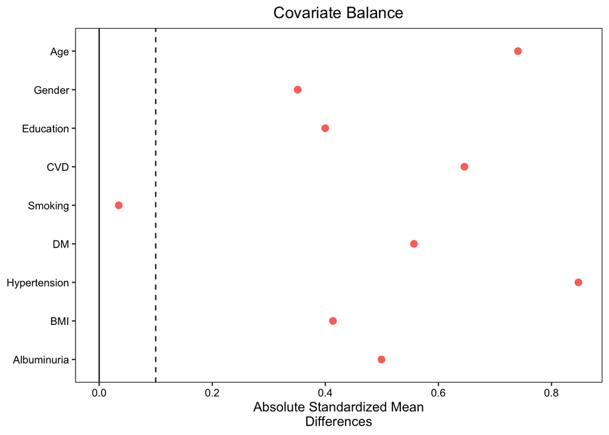

```r
love_plot_un <- bal.tab(
  Statin ~ Age + Gender + Education + CVD + Smoking + DM + Hypertension + BMI + Albuminuria,
  data = statin_db,
  un = TRUE,
  continuous = 'std',
  binary = 'std',
  abs = TRUE,
  s.d.denom = 'pooled',
  stats = c('mean.diffs', 'variance.ratios')
) %>% love.plot(thresholds = 0.1)

love_plot_un + theme(legend.position ='none')
```

## Outcome analysis (without weighting)

The effect of statin use on cognitive functions is firstly evaluated without taking in consideration the unbalance between groups.

```r
crude_estimation <- lm(RFFT ~ Statin, data = statin_db)
summary(crude_estimation)
```

```
##
## Call:
## lm(formula = RFFT ~ Statin, data = statin_db)
##
## Residuals:
##     Min      1Q  Median      3Q     Max
## -58.508 -19.508  -1.445  17.492  92.555
##
## Coefficients:
##             Estimate Std. Error t value Pr(>|t|)
## (Intercept)  71.5080     0.4509  158.59   <2e-16 ***
## Statin1     -13.0633     0.9596  -13.61   <2e-16 ***
## ---
## Signif. codes:  0 '***' 0.001 '**' 0.01 '*' 0.05 '.' 0.1 ' ' 1
##
## Residual standard error: 25.47 on 4093 degrees of freedom
## Multiple R-squared:  0.04331,    Adjusted R-squared:  0.04308
## F-statistic: 185.3 on 1 and 4093 DF,  p-value: < 2.2e-16
```

According to the estimation, statin use has a *significant negative effect on cognitive functions*.

## Propensity score estimation

Let’s now estimate the propensity score, the conditional probability of assignment to a particular treatment given a series of baseline covariates. Three different methods are used:

- Logistic Regression (LR) (method `ps`)
- Covariate Balancing Propensity Score (CBPS) (method `cbps`)
- Gradient-boosted Models (GBM) (method `gbm`)

To estimate the propensity score, the `weightit` function from the `WeightIt` package is used that, beyond estimating weights, also allows PS estimation.

```r
set.seed(42) #Set a random seed for reproducibility

methods <- c('ps','cbps','gbm')

weightit_list <- map(
  methods,
  ~ weightit(
    Statin ~ Age + Gender + Education + CVD + Smoking + DM + Hypertension + BMI + Albuminuria,
    data = statin_db,
    method = .x,
    estimand = 'ATE',
    stop.method = 'es.mean'
  )
) %>% set_names(., nm = methods)
```

### Common Support Evaluation

Let’s now extract the propensity scores and evaluate the common support.

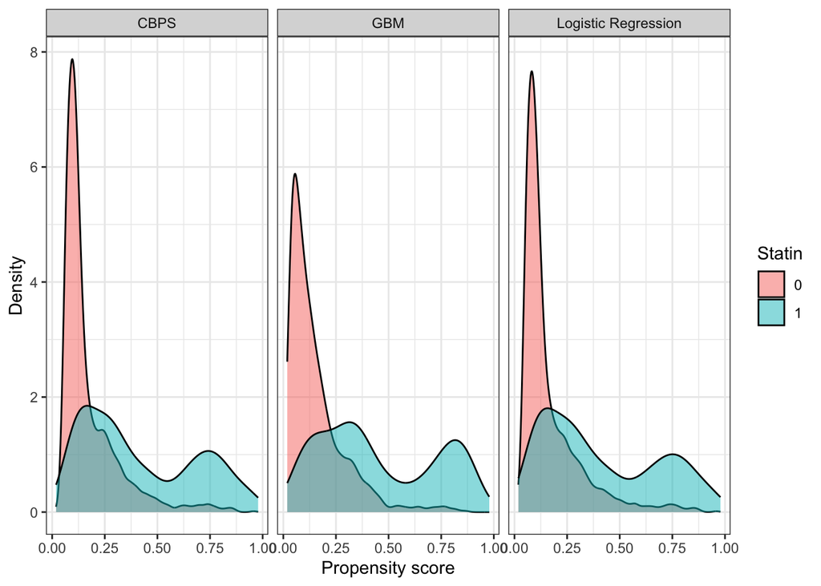

```r
statin_db_ps <- statin_db[,c(1:26,32)] %>%
  mutate(`Logistic Regression` = weightit_list$ps$ps,
         `CBPS` = weightit_list$cbps$ps,
         `GBM` = weightit_list$gbm$ps)

statin_db_long <- pivot_longer(statin_db_ps, cols = c(28:ncol(statin_db_ps)), names_to = 'method', values_to = 'ps_value')

ggplot(data = statin_db_long, aes(x = ps_value, y = after_stat(density), fill = Statin)) +
  geom_density(alpha = 0.5) +
  theme_bw() +
  facet_wrap(~ method)+
  labs(x = 'Propensity score', y = 'Density')
```

Evaluation of common support showed that all three PS estimation methods (LR, CBPS, GBM) demonstrated a moderate overlap between the two groups. Notably, in the control group, there was a high density of scores near 0, indicating some subjects with very low probabilities of receiving the treatment.

For the following analyses, PS estimated using Logistic Regression are used.

## Inverse Probability Weighting (IPW) with Trimming

IPW assigns each patient a weight that is the reciprocal of its estimated PS. Weight trimming refers to the reduction of weights larger than that at a given quantile q to the weight at that given quantile. This can be useful in controlling for extreme weights, which can cause bias and large variability in the estimated effect.

Trimmings at different quantiles are evaluated:

- Trimming at q = 0.9
- Trimming at q = 0.95
- Trimming at q = 0.99

### Covariate balance

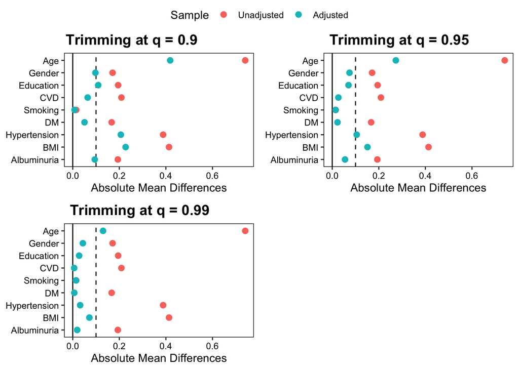

```r
weightit_trimming_cutoff <- weightit(
  Statin ~ Age + Gender + Education + CVD + Smoking + DM + Hypertension + BMI + Albuminuria,
  data = statin_db,
  method = 'ps',
  estimand = 'ATE' #IPW
)

statin_db_trimming_cutoffs = statin_db %>%
  mutate(wt_0.9 = trim(weightit_trimming_cutoff$weights, at = 0.9, treat = statin_db$Statin),
         wt_0.95 = trim(weightit_trimming_cutoff$weights, at = 0.95, treat = statin_db$Statin),
         wt_0.99 = trim(weightit_trimming_cutoff$weights, at = .99, treat = statin_db$Statin),
         wt = weightit_trimming_cutoff$weights)

trimming_cutoffs_bals <- map(
  c('wt_0.9','wt_0.95','wt_0.99'),
  ~ bal.tab(x = statin_db_trimming_cutoffs[,c('Age','Gender','Education','CVD','Smoking','DM', 'Hypertension', 'BMI', 'Albuminuria')], treat = statin_db_trimming_cutoffs$Statin, weights = statin_db_trimming_cutoffs[,.x], un = TRUE, abs = TRUE, s.d.denom = 'pooled', stats = c('mean.diffs', 'variance.ratios'))) %>% set_names(., nm = c('Trimming at q = 0.9', 'Trimming at q = 0.95', 'Trimming at q = 0.99'))

love_plots_trimming_cutoffs <- map(
  trimming_cutoffs_bals,
  ~ {love.plot(.x, thresholds = 0.1) + labs(title = '')}
)

ggarrange(plotlist = love_plots_trimming_cutoffs,common.legend = T, labels = names(trimming_cutoffs_bals))
```

### Outcome estimation

Let’s now evaluate the effect of statin use on RFFT score, using the weights calculated using IPW at different trimming cutoffs.

```r
#IPW with trimming at q=0.9
svy_design <- svydesign(
  ids = ~ 1,
  weights = ~ wt_0.9,
  data = statin_db_trimming_cutoffs
)

out_model_statin <- svyglm(
  RFFT ~ Statin,
  design = svy_design,
  family = gaussian()
)

summary(out_model_statin)
```

```
##
## Call:
## svyglm(formula = RFFT ~ Statin, design = svy_design, family = gaussian())
##
## Survey design:
## svydesign(ids = ~1, weights = ~wt_0.9, data = statin_db_trimming_cutoffs)
##
## Coefficients:
##             Estimate Std. Error t value Pr(>|t|)
## (Intercept)  68.9154     0.5001 137.809  < 2e-16 ***
## Statin1      -7.6587     0.9903  -7.734  1.3e-14 ***
## ---
## Signif. codes:  0 '***' 0.001 '**' 0.01 '*' 0.05 '.' 0.1 ' ' 1
##
## (Dispersion parameter for gaussian family taken to be 642.1445)
##
## Number of Fisher Scoring iterations: 2
```

```r
#IPW with trimming at q=0.95
svy_design_0.95 <- svydesign(
  ids = ~ 1,
  weights = ~ wt_0.95,
  data = statin_db_trimming_cutoffs
)

out_model_statin_0.95 <- svyglm(
  RFFT ~ Statin,
  design = svy_design_0.95,
  family = gaussian()
)

summary(out_model_statin_0.95)
```

```
##
## Call:
## svyglm(formula = RFFT ~ Statin, design = svy_design_0.95, family = gaussian())
##
## Survey design:
## svydesign(ids = ~1, weights = ~wt_0.95, data = statin_db_trimming_cutoffs)
##
## Coefficients:
##             Estimate Std. Error t value Pr(>|t|)
## (Intercept)   68.559      0.523 131.080  < 2e-16 ***
## Statin1       -5.366      1.073  -5.002 5.93e-07 ***
## ---
## Signif. codes:  0 '***' 0.001 '**' 0.01 '*' 0.05 '.' 0.1 ' ' 1
##
## (Dispersion parameter for gaussian family taken to be 643.4276)
##
## Number of Fisher Scoring iterations: 2
```

```r
#IPW with trimming at q=0.99
svy_design_0.99 <- svydesign(
  ids = ~ 1,
  weights = ~ wt_0.99,
  data = statin_db_trimming_cutoffs
)

out_model_statin_0.99 <- svyglm(
  RFFT ~ Statin,
  design = svy_design_0.99,
  family = gaussian()
)

summary(out_model_statin_0.99)
```

```
##
## Call:
## svyglm(formula = RFFT ~ Statin, design = svy_design_0.99, family = gaussian())
##
## Survey design:
## svydesign(ids = ~1, weights = ~wt_0.99, data = statin_db_trimming_cutoffs)
##
## Coefficients:
##             Estimate Std. Error t value Pr(>|t|)
## (Intercept)  68.3962     0.5453 125.434  < 2e-16 ***
## Statin1      -3.1139     1.1768  -2.646  0.00818 **
## ---
## Signif. codes:  0 '***' 0.001 '**' 0.01 '*' 0.05 '.' 0.1 ' ' 1
##
## (Dispersion parameter for gaussian family taken to be 646.807)
##
## Number of Fisher Scoring iterations: 2
```

## Overlap Weighting

Overlap Weighting (OW) is a weighting technique in which each unit’s weight is defined as the probability of that unit being assigned to the opposite group. Given its formulation, patients with propensity scores near 0.5 make the largest contribution, while patients with PSs near 0 and 1 make the smallest contribution.

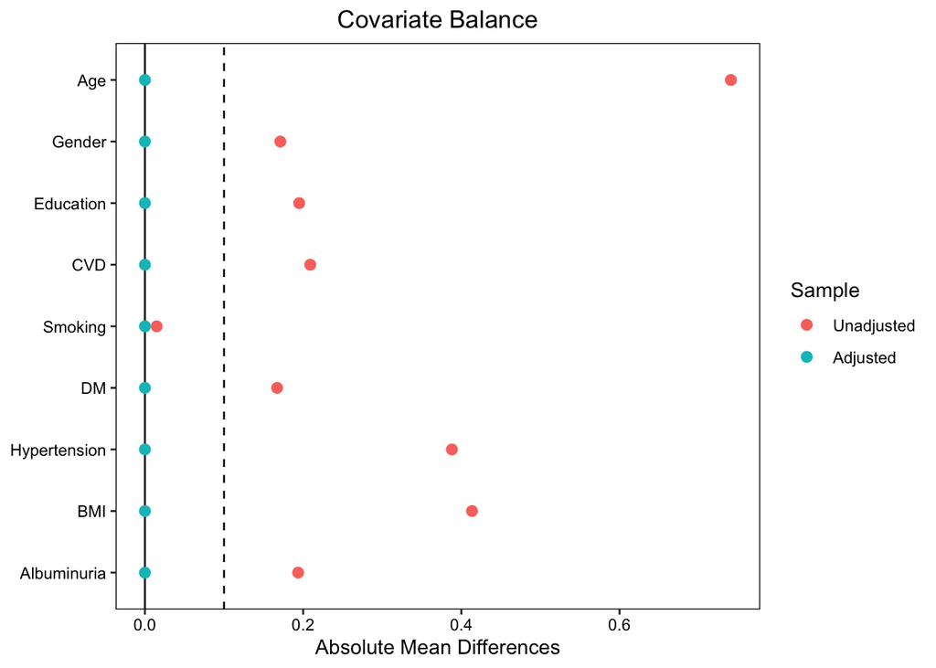

```r
#OW weights calculation

OW_trimming_cutoff <- weightit(
  Statin ~ Age + Gender + Education + CVD + Smoking + DM + Hypertension + BMI + Albuminuria,
  data = statin_db,
  method = 'ps',
  estimand = 'ATO' #OW
)

statin_db_overlap_wt <- statin_db %>%
  mutate(overlap_wt = OW_trimming_cutoff$weights)

OW_bal_tab <- bal.tab(x = statin_db_overlap_wt[,c('Age','Gender','Education','CVD','Smoking','DM', 'Hypertension', 'BMI', 'Albuminuria')], treat = statin_db_overlap_wt$Statin, weights = statin_db_overlap_wt[,'overlap_wt'], un = TRUE, abs = TRUE, s.d.denom = 'pooled', stats = c('mean.diffs', 'variance.ratios'))

love_plot_ow <- love.plot(OW_bal_tab, thresholds = 0.1)
love_plot_ow
```

If we compare the covariate balance across the different weighting methods:

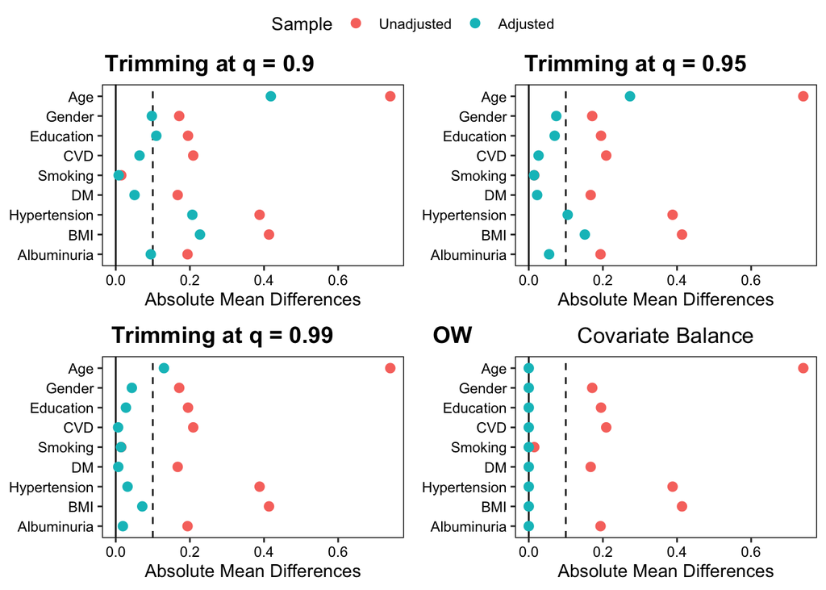

```r
final_love_plot_list <- c(love_plots_trimming_cutoffs, list(love_plot_ow)) %>%
  set_names(., nm = c(names(love_plots_trimming_cutoffs), "OW"))
ggarrange(plotlist = final_love_plot_list,common.legend = T, labels = names(final_love_plot_list))
```

we can see that IPW trimming at q = 0.9 led to the least favourable balance scenario, while achieving the best balance resulted from trimming weights at q = 0.99. Moreover, weighting subjects with OW yielded nearly a perfect balance, as expected.

### Outcome estimation

The estimated effect of statin use on cognitive function after overlap weighting is:

```r
svy_design_overlap <- svydesign(
  ids = ~1,
  weights = ~ overlap_wt,
  data = statin_db_overlap_wt
)

out_model_overlap <- svyglm(
  RFFT ~ Statin,
  design = svy_design_overlap,
  family = gaussian()
)

summary(out_model_overlap)
```

```
##
## Call:
## svyglm(formula = RFFT ~ Statin, design = svy_design_overlap,
##     family = gaussian())
##
## Survey design:
## svydesign(ids = ~1, weights = ~overlap_wt, data = statin_db_overlap_wt)
##
## Coefficients:
##             Estimate Std. Error t value Pr(>|t|)
## (Intercept)  62.8458     0.5791 108.522   <2e-16 ***
## Statin1      -0.9179     1.0504  -0.874    0.382
## ---
## Signif. codes:  0 '***' 0.001 '**' 0.01 '*' 0.05 '.' 0.1 ' ' 1
##
## (Dispersion parameter for gaussian family taken to be 602.6103)
##
## Number of Fisher Scoring iterations: 2
```

## Comparing the results

```r
(map_df(list(crude_estimation, out_model_statin, out_model_statin_0.95,out_model_statin_0.99, out_model_overlap), ~{data.frame(summary(.x)$coefficients[2,1], confint(.x)[2,1], confint(.x)[2,2], summary(.x)$coefficients[2,4])}) %>% `colnames<-`(., c('B', 'LOWER 95% CI', 'UPPER 95% CI', 'p-value')) %>%
  `rownames<-`(., c('Crude', 'IPW Trimming 0.9', 'IPW Trimming 0.95', 'IPW Trimming 0.99', 'OW')))
```

```
##                             B LOWER 95% CI UPPER 95% CI      p-value
## Crude             -13.0633010   -14.944721  -11.1818807 2.636739e-41
## IPW Trimming 0.9   -7.6587403    -9.600227   -5.7172533 1.304227e-14
## IPW Trimming 0.95  -5.3662359    -7.469733   -3.2627389 5.925619e-07
## IPW Trimming 0.99  -3.1138680    -5.421125   -0.8066107 8.177485e-03
## OW                 -0.9178727    -2.977288    1.1415431 3.822753e-01
```

## Treatment duration

To assess the effect of treatment duration on cognitive functions, the same approach can be used.

### Outcome estimation (without weighting)

```r
statin_db <- statin_db %>%
  mutate(Years_corrected = ifelse(statin_db$Years == -1, 0, statin_db$Years))

statin_db_trimming_cutoffs <- statin_db_trimming_cutoffs %>%
  mutate(Years_corrected = ifelse(statin_db_trimming_cutoffs$Years == -1, 0, statin_db_trimming_cutoffs$Years))

statin_db_overlap_wt <- statin_db_overlap_wt %>%
    mutate(Years_corrected = ifelse(statin_db_overlap_wt$Years == -1, 0, statin_db_overlap_wt$Years))
```

```r
crude_estimation_years <- lm(RFFT ~ Years_corrected, data = statin_db)

summary(crude_estimation_years)
```

```
##
## Call:
## lm(formula = RFFT ~ Years_corrected, data = statin_db)
##
## Residuals:
##     Min      1Q  Median      3Q     Max
## -57.589 -20.035  -1.113  17.411  86.411
##
## Coefficients:
##                 Estimate Std. Error t value Pr(>|t|)
## (Intercept)      70.5888     0.4346  162.42   <2e-16 ***
## Years_corrected  -2.5679     0.2210  -11.62   <2e-16 ***
## ---
## Signif. codes:  0 '***' 0.001 '**' 0.01 '*' 0.05 '.' 0.1 ' ' 1
##
## Residual standard error: 25.62 on 4093 degrees of freedom
## Multiple R-squared:  0.03195,    Adjusted R-squared:  0.03171
## F-statistic: 135.1 on 1 and 4093 DF,  p-value: < 2.2e-16
```

## Outcome estimation (IPW)

```r
#IPW with trimming at q=0.9
svy_design <- svydesign(
  ids = ~ 1,
  weights = ~ wt_0.9,
  data = statin_db_trimming_cutoffs
)

out_model_statin_years <- svyglm(
  RFFT ~ Years_corrected,
  design = svy_design,
  family = gaussian()
)

summary(out_model_statin_years)
```

```
##
## Call:
## svyglm(formula = RFFT ~ Years_corrected, design = svy_design,
##     family = gaussian())
##
## Survey design:
## svydesign(ids = ~1, weights = ~wt_0.9, data = statin_db_trimming_cutoffs)
##
## Coefficients:
##                 Estimate Std. Error t value Pr(>|t|)
## (Intercept)      68.0860     0.4799 141.881  < 2e-16 ***
## Years_corrected  -1.6201     0.2161  -7.498 7.91e-14 ***
## ---
## Signif. codes:  0 '***' 0.001 '**' 0.01 '*' 0.05 '.' 0.1 ' ' 1
##
## (Dispersion parameter for gaussian family taken to be 644.0444)
##
## Number of Fisher Scoring iterations: 2
```

```r
#IPW with trimming at q=0.95
svy_design <- svydesign(
  ids = ~ 1,
  weights = ~ wt_0.95,
  data = statin_db_trimming_cutoffs
)

out_model_statin_0.95_years <- svyglm(
  RFFT ~ Years_corrected,
  design = svy_design,
  family = gaussian()
)

summary(out_model_statin_0.95_years)
```

```
##
## Call:
## svyglm(formula = RFFT ~ Years_corrected, design = svy_design,
##     family = gaussian())
##
## Survey design:
## svydesign(ids = ~1, weights = ~wt_0.95, data = statin_db_trimming_cutoffs)
##
## Coefficients:
##                 Estimate Std. Error t value Pr(>|t|)
## (Intercept)      67.9125     0.5138 132.184  < 2e-16 ***
## Years_corrected  -1.1692     0.2440  -4.792 1.71e-06 ***
## ---
## Signif. codes:  0 '***' 0.001 '**' 0.01 '*' 0.05 '.' 0.1 ' ' 1
##
## (Dispersion parameter for gaussian family taken to be 644.0312)
##
## Number of Fisher Scoring iterations: 2
```

```r
#IPW with trimming at q=0.99
svy_design <- svydesign(
  ids = ~ 1,
  weights = ~ wt_0.99,
  data = statin_db_trimming_cutoffs
)

out_model_statin_0.99_years <- svyglm(
  RFFT ~ Years_corrected,
  design = svy_design,
  family = gaussian()
)

summary(out_model_statin_0.99_years)
```

```
##
## Call:
## svyglm(formula = RFFT ~ Years_corrected, design = svy_design,
##     family = gaussian())
##
## Survey design:
## svydesign(ids = ~1, weights = ~wt_0.99, data = statin_db_trimming_cutoffs)
##
## Coefficients:
##                 Estimate Std. Error t value Pr(>|t|)
## (Intercept)      68.0996     0.5575 122.155  < 2e-16 ***
## Years_corrected  -0.7588     0.2809  -2.701  0.00693 **
## ---
## Signif. codes:  0 '***' 0.001 '**' 0.01 '*' 0.05 '.' 0.1 ' ' 1
##
## (Dispersion parameter for gaussian family taken to be 646.4364)
##
## Number of Fisher Scoring iterations: 2
```

## Outcome estimation (Overlap Weighting)

```r
svy_design <- svydesign(
  ids = ~ 1,
  weights = ~ overlap_wt,
  data = statin_db_overlap_wt
)

out_model_statin_overlap_years <- svyglm(
  RFFT ~ Years_corrected,
  design = svy_design,
  family = gaussian()
)

summary(out_model_statin_overlap_years)
```

```
##
## Call:
## svyglm(formula = RFFT ~ Years_corrected, design = svy_design,
##     family = gaussian())
##
## Survey design:
## svydesign(ids = ~1, weights = ~overlap_wt, data = statin_db_overlap_wt)
##
## Coefficients:
##                 Estimate Std. Error t value Pr(>|t|)
## (Intercept)      63.1010     0.5679 111.113   <2e-16 ***
## Years_corrected  -0.4281     0.2366  -1.809   0.0705 .
## ---
## Signif. codes:  0 '***' 0.001 '**' 0.01 '*' 0.05 '.' 0.1 ' ' 1
##
## (Dispersion parameter for gaussian family taken to be 601.8759)
##
## Number of Fisher Scoring iterations: 2
```

### Comparison of estimates (treatment duration)

```r
(map_df(list(crude_estimation_years, out_model_statin_years, out_model_statin_0.95_years,out_model_statin_0.99_years, out_model_statin_overlap_years), ~{data.frame(summary(.x)$coefficients[2,1], confint(.x)[2,1], confint(.x)[2,2], summary(.x)$coefficients[2,4])}) %>% `colnames<-`(., c('B', 'LOWER 95% CI', 'UPPER 95% CI', 'p-value')) %>%
  `rownames<-`(., c('Crude', 'IPW Trimming 0.9', 'IPW Trimming 0.95', 'IPW Trimming 0.99', 'OW')))
```

```
##                            B LOWER 95% CI UPPER 95% CI      p-value
## Crude             -2.5678627   -3.0010462  -2.13467909 9.647546e-31
## IPW Trimming 0.9  -1.6200854   -2.0437055  -1.19646526 7.907087e-14
## IPW Trimming 0.95 -1.1691890   -1.6475196  -0.69085830 1.708299e-06
## IPW Trimming 0.99 -0.7588399   -1.3095545  -0.20812517 6.931838e-03
## OW                -0.4281381   -0.8920467   0.03577055 7.046651e-02
```

A significant reduction of RFFT score with the increase of time was estimated both with the unadjusted model and in the IPW-adjusted models. Also, in this case, OW estimation evaluated a non-significant effect of statin use on cognitive functions (B =-0.43, p=0.07).

**Altogether, these results highlighted how choosing different weighting approaches can lead to very different results.**

## References

- Joosten H, Visser ST, Eersel ME van, Gansevoort RT, Bilo HJG, Slaets JP, et al. Statin Use and Cognitive Function: Population-Based Observational Study with Long-Term Follow-Up. PLOS ONE. 2014;9:e115755.
- Ruff RM, Light RH, Evans RW. The ruff figural fluency test: A normative study with adults. Developmental Neuropsychology. 1987;3:37–51.
- Rosenbaum PR, Rubin DB. The Central Role of the Propensity Score in Observational Studies for Causal Effects. Biometrika. 1983;70:41–55.
- Austin PC, Stuart EA. Moving towards best practice when using inverse probability of treatment weighting (IPTW) using the propensity score to estimate causal treatment effects in observational studies. Stat Med. 2015;34:3661–79.
- Li F, Thomas LE. Addressing Extreme Propensity Scores via the Overlap Weights. American Journal of Epidemiology. 2018. https://doi.org/10.1093/aje/kwy201.